# Risk Factor Analysis

## Outcome Variable

**Outcome Variable:** haz

## Predictor Variables

**Intervention Variable:** anywast06

**Adjustment Set:**

unadjusted

## Stratifying Variables

The analysis was stratified on these variable(s):

- agecat
- studyid
- country

## Data Summary

| agecat | studyid | country | anywast06 | n_cell | n |
| --- | --- | --- | --- | --- | --- |
| Birth | CMC-V-BCS-2002 | INDIA | 0 | 37 | 92 |
| Birth | CMC-V-BCS-2002 | INDIA | 1 | 55 | 92 |
| Birth | CMIN | BANGLADESH | 0 | 15 | 20 |
| Birth | CMIN | BANGLADESH | 1 | 5 | 20 |
| Birth | CONTENT | PERU | 0 | 2 | 2 |
| Birth | CONTENT | PERU | 1 | 0 | 2 |
| Birth | EE | PAKISTAN | 0 | 156 | 240 |
| Birth | EE | PAKISTAN | 1 | 84 | 240 |
| Birth | GMS-Nepal | NEPAL | 0 | 422 | 684 |
| Birth | GMS-Nepal | NEPAL | 1 | 262 | 684 |
| Birth | IRC | INDIA | 0 | 164 | 388 |
| Birth | IRC | INDIA | 1 | 224 | 388 |
| Birth | Keneba | GAMBIA | 0 | 994 | 1542 |
| Birth | Keneba | GAMBIA | 1 | 548 | 1542 |
| Birth | MAL-ED | BANGLADESH | 0 | 177 | 229 |
| Birth | MAL-ED | BANGLADESH | 1 | 52 | 229 |
| Birth | MAL-ED | BRAZIL | 0 | 62 | 65 |
| Birth | MAL-ED | BRAZIL | 1 | 3 | 65 |
| Birth | MAL-ED | INDIA | 0 | 33 | 47 |
| Birth | MAL-ED | INDIA | 1 | 14 | 47 |
| Birth | MAL-ED | NEPAL | 0 | 23 | 27 |
| Birth | MAL-ED | NEPAL | 1 | 4 | 27 |
| Birth | MAL-ED | PERU | 0 | 223 | 233 |
| Birth | MAL-ED | PERU | 1 | 10 | 233 |
| Birth | MAL-ED | SOUTH AFRICA | 0 | 101 | 122 |
| Birth | MAL-ED | SOUTH AFRICA | 1 | 21 | 122 |
| Birth | MAL-ED | TANZANIA, UNITED REPUBLIC OF | 0 | 119 | 124 |
| Birth | MAL-ED | TANZANIA, UNITED REPUBLIC OF | 1 | 5 | 124 |
| Birth | PROVIDE | BANGLADESH | 0 | 396 | 539 |
| Birth | PROVIDE | BANGLADESH | 1 | 143 | 539 |

[output cut: 70 more lines]

The following strata were considered:

- agecat: 24 months, studyid: CMC-V-BCS-2002, country: INDIA
- agecat: 24 months, studyid: CMIN, country: BANGLADESH
- agecat: 24 months, studyid: CONTENT, country: PERU
- agecat: 24 months, studyid: EE, country: PAKISTAN
- agecat: 24 months, studyid: GMS-Nepal, country: NEPAL
- agecat: 24 months, studyid: IRC, country: INDIA
- agecat: 24 months, studyid: Keneba, country: GAMBIA
- agecat: 24 months, studyid: MAL-ED, country: BANGLADESH
- agecat: 24 months, studyid: MAL-ED, country: BRAZIL
- agecat: 24 months, studyid: MAL-ED, country: INDIA
- agecat: 24 months, studyid: MAL-ED, country: NEPAL
- agecat: 24 months, studyid: MAL-ED, country: PERU
- agecat: 24 months, studyid: MAL-ED, country: SOUTH AFRICA
- agecat: 24 months, studyid: MAL-ED, country: TANZANIA, UNITED REPUBLIC OF
- agecat: 24 months, studyid: PROVIDE, country: BANGLADESH
- agecat: 24 months, studyid: TanzaniaChild2, country: TANZANIA, UNITED REPUBLIC OF
- agecat: 6 months, studyid: CMC-V-BCS-2002, country: INDIA
- agecat: 6 months, studyid: CMIN, country: BANGLADESH
- agecat: 6 months, studyid: CONTENT, country: PERU
- agecat: 6 months, studyid: EE, country: PAKISTAN
- agecat: 6 months, studyid: GMS-Nepal, country: NEPAL
- agecat: 6 months, studyid: Guatemala BSC, country: GUATEMALA
- agecat: 6 months, studyid: IRC, country: INDIA
- agecat: 6 months, studyid: Keneba, country: GAMBIA
- agecat: 6 months, studyid: MAL-ED, country: BANGLADESH
- agecat: 6 months, studyid: MAL-ED, country: BRAZIL
- agecat: 6 months, studyid: MAL-ED, country: INDIA
- agecat: 6 months, studyid: MAL-ED, country: NEPAL
- agecat: 6 months, studyid: MAL-ED, country: PERU
- agecat: 6 months, studyid: MAL-ED, country: SOUTH AFRICA
- agecat: 6 months, studyid: MAL-ED, country: TANZANIA, UNITED REPUBLIC OF
- agecat: 6 months, studyid: PROVIDE, country: BANGLADESH
- agecat: 6 months, studyid: ResPak, country: PAKISTAN
- agecat: 6 months, studyid: TanzaniaChild2, country: TANZANIA, UNITED REPUBLIC OF
- agecat: Birth, studyid: CMC-V-BCS-2002, country: INDIA
- agecat: Birth, studyid: CMIN, country: BANGLADESH
- agecat: Birth, studyid: CONTENT, country: PERU
- agecat: Birth, studyid: EE, country: PAKISTAN
- agecat: Birth, studyid: GMS-Nepal, country: NEPAL
- agecat: Birth, studyid: IRC, country: INDIA
- agecat: Birth, studyid: Keneba, country: GAMBIA
- agecat: Birth, studyid: MAL-ED, country: BANGLADESH
- agecat: Birth, studyid: MAL-ED, country: BRAZIL
- agecat: Birth, studyid: MAL-ED, country: INDIA
- agecat: Birth, studyid: MAL-ED, country: NEPAL
- agecat: Birth, studyid: MAL-ED, country: PERU
- agecat: Birth, studyid: MAL-ED, country: SOUTH AFRICA
- agecat: Birth, studyid: MAL-ED, country: TANZANIA, UNITED REPUBLIC OF
- agecat: Birth, studyid: PROVIDE, country: BANGLADESH
- agecat: Birth, studyid: ResPak, country: PAKISTAN

### Dropped Strata

Some strata were dropped due to rare outcomes:

- agecat: Birth, studyid: CONTENT, country: PERU
- agecat: Birth, studyid: MAL-ED, country: BRAZIL
- agecat: Birth, studyid: MAL-ED, country: NEPAL
- agecat: 6 months, studyid: CONTENT, country: PERU
- agecat: 24 months, studyid: CONTENT, country: PERU
- agecat: 24 months, studyid: TanzaniaChild2, country: TANZANIA, UNITED REPUBLIC OF

## Methods Detail

We’re interested in the causal parameters $E[Y_a]$ for all values of $a \in \mathcal{A}$. These parameters represent the mean outcome if, possibly contrary to fact, we intervened to set all units to have $A=a$. Under the randomization and positivity assumptions, these are identified by the statistical parameters $\psi_a=E_W[E_{Y|A,W}(Y|A=a,W)]$. In addition, we’re interested in the mean of $Y$, $E[Y]$ under no intervention (the observed mean). We will estimate these parameters by using SuperLearner to fit the relevant likelihood factors – $E_{Y|A,W}(Y|A=a,W)$ and $p(A=a|W)$, and then updating our likelihood fit using a joint TMLE.

For unadjusted analyses ($W=\{\}$), initial likelihoods were estimated using Lrnr_glm to estimate the simple $E(Y|A)$ and Lrnr_mean to estimate $p(A)$. For adjusted analyses, a small library containing Lrnr_glmnet, Lrnr_xgboost, and Lrnr_mean was used.

Having estimated these parameters, we will then use the delta method to estimate relative risks and attributable risks relative to a prespecified baseline level of $A$.

# Results Detail

## Results Plots

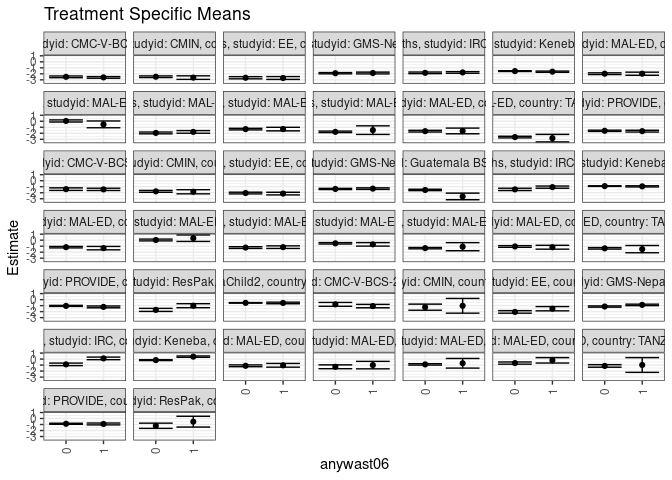

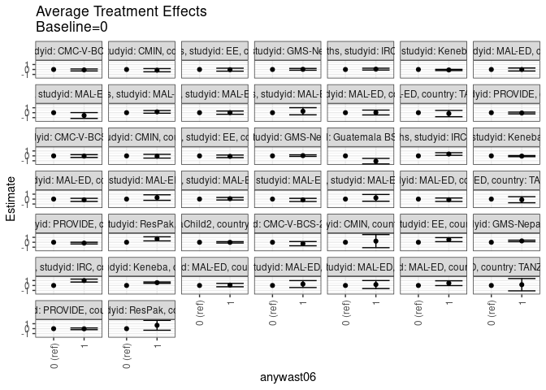

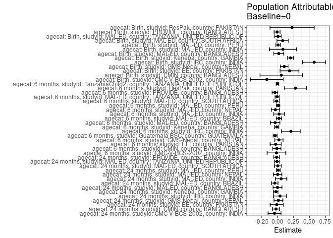

## Results Table

### Parameter: TSM

| agecat | studyid | country | intervention_level | baseline_level | estimate | ci_lower | ci_upper |
| --- | --- | --- | --- | --- | --- | --- | --- |
| Birth | CMC-V-BCS-2002 | INDIA | 0 | NA | -0.7910811 | -1.1115551 | -0.4706071 |
| Birth | CMC-V-BCS-2002 | INDIA | 1 | NA | -1.0756364 | -1.3626405 | -0.7886323 |
| Birth | CMIN | BANGLADESH | 0 | NA | -1.2613333 | -1.7710980 | -0.7515686 |
| Birth | CMIN | BANGLADESH | 1 | NA | -1.0280000 | -2.2553082 | 0.1993082 |
| Birth | EE | PAKISTAN | 0 | NA | -2.0487821 | -2.2576622 | -1.8399019 |
| Birth | EE | PAKISTAN | 1 | NA | -1.5119048 | -1.8688110 | -1.1549986 |
| Birth | GMS-Nepal | NEPAL | 0 | NA | -1.1500474 | -1.2507864 | -1.0493084 |
| Birth | GMS-Nepal | NEPAL | 1 | NA | -0.8769847 | -0.9974556 | -0.7565139 |
| Birth | IRC | INDIA | 0 | NA | -0.8824390 | -1.0921018 | -0.6727762 |
| Birth | IRC | INDIA | 1 | NA | 0.1125000 | -0.1037740 | 0.3287740 |
| Birth | Keneba | GAMBIA | 0 | NA | -0.1706539 | -0.2451175 | -0.0961904 |
| Birth | Keneba | GAMBIA | 1 | NA | 0.4011314 | 0.2902414 | 0.5120214 |
| Birth | MAL-ED | BANGLADESH | 0 | NA | -1.1225989 | -1.2702265 | -0.9749713 |
| Birth | MAL-ED | BANGLADESH | 1 | NA | -1.0411538 | -1.3516184 | -0.7306893 |
| Birth | MAL-ED | INDIA | 0 | NA | -1.2875758 | -1.6077743 | -0.9673772 |
| Birth | MAL-ED | INDIA | 1 | NA | -1.0057143 | -1.6296563 | -0.3817722 |
| Birth | MAL-ED | PERU | 0 | NA | -0.8908520 | -1.0079254 | -0.7737786 |
| Birth | MAL-ED | PERU | 1 | NA | -0.7030000 | -1.5047818 | 0.0987818 |
| Birth | MAL-ED | SOUTH AFRICA | 0 | NA | -0.6670297 | -0.8519500 | -0.4821094 |
| Birth | MAL-ED | SOUTH AFRICA | 1 | NA | -0.2066667 | -0.6579509 | 0.2446176 |
| Birth | MAL-ED | TANZANIA, UNITED REPUBLIC OF | 0 | NA | -1.1432773 | -1.3541075 | -0.9324471 |
| Birth | MAL-ED | TANZANIA, UNITED REPUBLIC OF | 1 | NA | -0.9860000 | -2.2167588 | 0.2447588 |
| Birth | PROVIDE | BANGLADESH | 0 | NA | -0.8771465 | -0.9622990 | -0.7919940 |
| Birth | PROVIDE | BANGLADESH | 1 | NA | -0.9071329 | -1.0632053 | -0.7510604 |
| Birth | ResPak | PAKISTAN | 0 | NA | -1.2075000 | -1.6425384 | -0.7724616 |
| Birth | ResPak | PAKISTAN | 1 | NA | -0.5250000 | -1.4246107 | 0.3746107 |
| 6 months | CMC-V-BCS-2002 | INDIA | 0 | NA | -1.4063559 | -1.6195354 | -1.1931764 |
| 6 months | CMC-V-BCS-2002 | INDIA | 1 | NA | -1.4409752 | -1.6317181 | -1.2502323 |
| 6 months | CMIN | BANGLADESH | 0 | NA | -1.7727944 | -1.9229283 | -1.6226604 |
| 6 months | CMIN | BANGLADESH | 1 | NA | -1.8401587 | -2.1859411 | -1.4943764 |

[output cut: 58 more lines]

### Parameter: E(Y)

| agecat | studyid | country | intervention_level | baseline_level | estimate | ci_lower | ci_upper |
| --- | --- | --- | --- | --- | --- | --- | --- |
| Birth | CMC-V-BCS-2002 | INDIA | NA | NA | -0.9611957 | -1.1776967 | -0.7446946 |
| Birth | CMIN | BANGLADESH | NA | NA | -1.2030000 | -1.6953191 | -0.7106809 |
| Birth | EE | PAKISTAN | NA | NA | -1.8608750 | -2.0482045 | -1.6735455 |
| Birth | GMS-Nepal | NEPAL | NA | NA | -1.0454532 | -1.1235003 | -0.9674062 |
| Birth | IRC | INDIA | NA | NA | -0.3080412 | -0.4687931 | -0.1472894 |
| Birth | Keneba | GAMBIA | NA | NA | 0.0325486 | -0.0310420 | 0.0961393 |
| Birth | MAL-ED | BANGLADESH | NA | NA | -1.1041048 | -1.2383048 | -0.9699048 |
| Birth | MAL-ED | INDIA | NA | NA | -1.2036170 | -1.4976814 | -0.9095527 |
| Birth | MAL-ED | PERU | NA | NA | -0.8827897 | -1.0001058 | -0.7654736 |
| Birth | MAL-ED | SOUTH AFRICA | NA | NA | -0.5877869 | -0.7622273 | -0.4133464 |
| Birth | MAL-ED | TANZANIA, UNITED REPUBLIC OF | NA | NA | -1.1369355 | -1.3453337 | -0.9285373 |
| Birth | PROVIDE | BANGLADESH | NA | NA | -0.8851020 | -0.9601332 | -0.8100709 |
| Birth | ResPak | PAKISTAN | NA | NA | -0.9800000 | -1.4086438 | -0.5513562 |
| 6 months | CMC-V-BCS-2002 | INDIA | NA | NA | -1.4241872 | -1.5668135 | -1.2815609 |
| 6 months | CMIN | BANGLADESH | NA | NA | -1.7844376 | -1.9222926 | -1.6465825 |
| 6 months | EE | PAKISTAN | NA | NA | -2.0835567 | -2.2027557 | -1.9643578 |
| 6 months | GMS-Nepal | NEPAL | NA | NA | -1.3508392 | -1.4290633 | -1.2726152 |
| 6 months | Guatemala BSC | GUATEMALA | NA | NA | -1.5785476 | -1.6926664 | -1.4644288 |
| 6 months | IRC | INDIA | NA | NA | -1.2344062 | -1.3658524 | -1.1029600 |
| 6 months | Keneba | GAMBIA | NA | NA | -0.9116762 | -0.9588660 | -0.8644864 |
| 6 months | MAL-ED | BANGLADESH | NA | NA | -1.2049931 | -1.3222136 | -1.0877726 |
| 6 months | MAL-ED | BRAZIL | NA | NA | 0.0475758 | -0.0963508 | 0.1915023 |
| 6 months | MAL-ED | INDIA | NA | NA | -1.2115254 | -1.3298727 | -1.0931782 |
| 6 months | MAL-ED | NEPAL | NA | NA | -0.5615819 | -0.6741832 | -0.4489807 |
| 6 months | MAL-ED | PERU | NA | NA | -1.3236661 | -1.4316775 | -1.2156546 |
| 6 months | MAL-ED | SOUTH AFRICA | NA | NA | -1.0633202 | -1.1909180 | -0.9357224 |
| 6 months | MAL-ED | TANZANIA, UNITED REPUBLIC OF | NA | NA | -1.3687449 | -1.4907629 | -1.2467270 |
| 6 months | PROVIDE | BANGLADESH | NA | NA | -1.0916915 | -1.1661176 | -1.0172654 |
| 6 months | ResPak | PAKISTAN | NA | NA | -1.4314086 | -1.6374838 | -1.2253335 |
| 6 months | TanzaniaChild2 | TANZANIA, UNITED REPUBLIC OF | NA | NA | -0.5434389 | -0.5924056 | -0.4944722 |
| 24 months | CMC-V-BCS-2002 | INDIA | NA | NA | -2.5489071 | -2.6476125 | -2.4502017 |
| 24 months | CMIN | BANGLADESH | NA | NA | -2.5109504 | -2.6361514 | -2.3857494 |
| 24 months | EE | PAKISTAN | NA | NA | -2.6699900 | -2.8138051 | -2.5261749 |
| 24 months | GMS-Nepal | NEPAL | NA | NA | -1.8874180 | -1.9728588 | -1.8019773 |
| 24 months | IRC | INDIA | NA | NA | -1.7987775 | -1.8923914 | -1.7051636 |
| 24 months | Keneba | GAMBIA | NA | NA | -1.5774758 | -1.6295950 | -1.5253566 |
| 24 months | MAL-ED | BANGLADESH | NA | NA | -1.9783962 | -2.1050210 | -1.8517715 |
| 24 months | MAL-ED | BRAZIL | NA | NA | 0.0061144 | -0.1625850 | 0.1748138 |
| 24 months | MAL-ED | INDIA | NA | NA | -1.8861894 | -2.0110006 | -1.7613783 |
| 24 months | MAL-ED | NEPAL | NA | NA | -1.3075877 | -1.4270718 | -1.1881037 |
| 24 months | MAL-ED | PERU | NA | NA | -1.7524710 | -1.8736426 | -1.6312994 |
| 24 months | MAL-ED | SOUTH AFRICA | NA | NA | -1.6450595 | -1.7797240 | -1.5103950 |
| 24 months | MAL-ED | TANZANIA, UNITED REPUBLIC OF | NA | NA | -2.6455607 | -2.7807256 | -2.5103959 |
| 24 months | PROVIDE | BANGLADESH | NA | NA | -1.6024221 | -1.6857420 | -1.5191023 |

### Parameter: ATE

| agecat | studyid | country | intervention_level | baseline_level | estimate | ci_lower | ci_upper |
| --- | --- | --- | --- | --- | --- | --- | --- |
| Birth | CMC-V-BCS-2002 | INDIA | 0 | 0 | 0.0000000 | 0.0000000 | 0.0000000 |
| Birth | CMC-V-BCS-2002 | INDIA | 1 | 0 | -0.2845553 | -0.7147587 | 0.1456481 |
| Birth | CMIN | BANGLADESH | 0 | 0 | 0.0000000 | 0.0000000 | 0.0000000 |
| Birth | CMIN | BANGLADESH | 1 | 0 | 0.2333333 | -1.0956307 | 1.5622974 |
| Birth | EE | PAKISTAN | 0 | 0 | 0.0000000 | 0.0000000 | 0.0000000 |
| Birth | EE | PAKISTAN | 1 | 0 | 0.5368773 | 0.1233402 | 0.9504144 |
| Birth | GMS-Nepal | NEPAL | 0 | 0 | 0.0000000 | 0.0000000 | 0.0000000 |
| Birth | GMS-Nepal | NEPAL | 1 | 0 | 0.2730627 | 0.1160226 | 0.4301027 |
| Birth | IRC | INDIA | 0 | 0 | 0.0000000 | 0.0000000 | 0.0000000 |
| Birth | IRC | INDIA | 1 | 0 | 0.9949390 | 0.6937199 | 1.2961581 |
| Birth | Keneba | GAMBIA | 0 | 0 | 0.0000000 | 0.0000000 | 0.0000000 |
| Birth | Keneba | GAMBIA | 1 | 0 | 0.5717853 | 0.4382135 | 0.7053571 |
| Birth | MAL-ED | BANGLADESH | 0 | 0 | 0.0000000 | 0.0000000 | 0.0000000 |
| Birth | MAL-ED | BANGLADESH | 1 | 0 | 0.0814450 | -0.2623313 | 0.4252213 |
| Birth | MAL-ED | INDIA | 0 | 0 | 0.0000000 | 0.0000000 | 0.0000000 |
| Birth | MAL-ED | INDIA | 1 | 0 | 0.2818615 | -0.4194450 | 0.9831680 |
| Birth | MAL-ED | PERU | 0 | 0 | 0.0000000 | 0.0000000 | 0.0000000 |
| Birth | MAL-ED | PERU | 1 | 0 | 0.1878520 | -0.6224320 | 0.9981360 |
| Birth | MAL-ED | SOUTH AFRICA | 0 | 0 | 0.0000000 | 0.0000000 | 0.0000000 |
| Birth | MAL-ED | SOUTH AFRICA | 1 | 0 | 0.4603630 | -0.0273387 | 0.9480648 |
| Birth | MAL-ED | TANZANIA, UNITED REPUBLIC OF | 0 | 0 | 0.0000000 | 0.0000000 | 0.0000000 |
| Birth | MAL-ED | TANZANIA, UNITED REPUBLIC OF | 1 | 0 | 0.1572773 | -1.0914086 | 1.4059632 |
| Birth | PROVIDE | BANGLADESH | 0 | 0 | 0.0000000 | 0.0000000 | 0.0000000 |
| Birth | PROVIDE | BANGLADESH | 1 | 0 | -0.0299864 | -0.2077772 | 0.1478044 |
| Birth | ResPak | PAKISTAN | 0 | 0 | 0.0000000 | 0.0000000 | 0.0000000 |
| Birth | ResPak | PAKISTAN | 1 | 0 | 0.6825000 | -0.3167786 | 1.6817786 |
| 6 months | CMC-V-BCS-2002 | INDIA | 0 | 0 | 0.0000000 | 0.0000000 | 0.0000000 |
| 6 months | CMC-V-BCS-2002 | INDIA | 1 | 0 | -0.0346192 | -0.3206758 | 0.2514373 |
| 6 months | CMIN | BANGLADESH | 0 | 0 | 0.0000000 | 0.0000000 | 0.0000000 |
| 6 months | CMIN | BANGLADESH | 1 | 0 | -0.0673644 | -0.4443334 | 0.3096047 |

[output cut: 58 more lines]

### Parameter: PAR

| agecat | studyid | country | intervention_level | baseline_level | estimate | ci_lower | ci_upper |
| --- | --- | --- | --- | --- | --- | --- | --- |
| Birth | CMC-V-BCS-2002 | INDIA | 0 | NA | -0.1701146 | -0.4288941 | 0.0886650 |
| Birth | CMIN | BANGLADESH | 0 | NA | 0.0583333 | -0.2769994 | 0.3936660 |
| Birth | EE | PAKISTAN | 0 | NA | 0.1879071 | 0.0395728 | 0.3362413 |
| Birth | GMS-Nepal | NEPAL | 0 | NA | 0.1045942 | 0.0436232 | 0.1655652 |
| Birth | IRC | INDIA | 0 | NA | 0.5743978 | 0.3937355 | 0.7550601 |
| Birth | Keneba | GAMBIA | 0 | NA | 0.2032026 | 0.1538060 | 0.2525991 |
| Birth | MAL-ED | BANGLADESH | 0 | NA | 0.0184941 | -0.0596942 | 0.0966823 |
| Birth | MAL-ED | INDIA | 0 | NA | 0.0839587 | -0.1282362 | 0.2961537 |
| Birth | MAL-ED | PERU | 0 | NA | 0.0080623 | -0.0270572 | 0.0431818 |
| Birth | MAL-ED | SOUTH AFRICA | 0 | NA | 0.0792428 | -0.0102345 | 0.1687201 |
| Birth | MAL-ED | TANZANIA, UNITED REPUBLIC OF | 0 | NA | 0.0063418 | -0.0443044 | 0.0569881 |
| Birth | PROVIDE | BANGLADESH | 0 | NA | -0.0079556 | -0.0551378 | 0.0392267 |
| Birth | ResPak | PAKISTAN | 0 | NA | 0.2275000 | -0.1198462 | 0.5748462 |
| 6 months | CMC-V-BCS-2002 | INDIA | 0 | NA | -0.0178313 | -0.1651807 | 0.1295182 |
| 6 months | CMIN | BANGLADESH | 0 | NA | -0.0116432 | -0.0768773 | 0.0535909 |
| 6 months | EE | PAKISTAN | 0 | NA | -0.0303439 | -0.1173842 | 0.0566964 |
| 6 months | GMS-Nepal | NEPAL | 0 | NA | 0.0213383 | -0.0437784 | 0.0864550 |
| 6 months | Guatemala BSC | GUATEMALA | 0 | NA | -0.0384797 | -0.0693442 | -0.0076152 |
| 6 months | IRC | INDIA | 0 | NA | 0.2096864 | 0.0631417 | 0.3562310 |
| 6 months | Keneba | GAMBIA | 0 | NA | -0.0134582 | -0.0463625 | 0.0194461 |
| 6 months | MAL-ED | BANGLADESH | 0 | NA | -0.0386270 | -0.1135089 | 0.0362550 |
| 6 months | MAL-ED | BRAZIL | 0 | NA | 0.0217338 | -0.0197779 | 0.0632456 |
| 6 months | MAL-ED | INDIA | 0 | NA | 0.0241035 | -0.0603677 | 0.1085747 |
| 6 months | MAL-ED | NEPAL | 0 | NA | -0.0343301 | -0.0987665 | 0.0301062 |
| 6 months | MAL-ED | PERU | 0 | NA | 0.0090621 | -0.0166228 | 0.0347470 |
| 6 months | MAL-ED | SOUTH AFRICA | 0 | NA | -0.0158987 | -0.0586066 | 0.0268093 |
| 6 months | MAL-ED | TANZANIA, UNITED REPUBLIC OF | 0 | NA | -0.0070355 | -0.0396625 | 0.0255914 |
| 6 months | PROVIDE | BANGLADESH | 0 | NA | -0.0422434 | -0.0866206 | 0.0021339 |
| 6 months | ResPak | PAKISTAN | 0 | NA | 0.2800366 | 0.1066035 | 0.4534696 |
| 6 months | TanzaniaChild2 | TANZANIA, UNITED REPUBLIC OF | 0 | NA | -0.0020514 | -0.0227550 | 0.0186521 |
| 24 months | CMC-V-BCS-2002 | INDIA | 0 | NA | -0.0479791 | -0.1505558 | 0.0545977 |
| 24 months | CMIN | BANGLADESH | 0 | NA | -0.0253504 | -0.0819853 | 0.0312845 |
| 24 months | EE | PAKISTAN | 0 | NA | -0.0136750 | -0.1169154 | 0.0895653 |
| 24 months | GMS-Nepal | NEPAL | 0 | NA | 0.0128931 | -0.0567690 | 0.0825551 |
| 24 months | IRC | INDIA | 0 | NA | 0.0389389 | -0.0648574 | 0.1427352 |
| 24 months | Keneba | GAMBIA | 0 | NA | -0.0282633 | -0.0633250 | 0.0067984 |
| 24 months | MAL-ED | BANGLADESH | 0 | NA | -0.0011123 | -0.0714904 | 0.0692658 |
| 24 months | MAL-ED | BRAZIL | 0 | NA | -0.0437147 | -0.0946281 | 0.0071987 |
| 24 months | MAL-ED | INDIA | 0 | NA | 0.0561947 | -0.0334670 | 0.1458564 |
| 24 months | MAL-ED | NEPAL | 0 | NA | 0.0013134 | -0.0643125 | 0.0669393 |
| 24 months | MAL-ED | PERU | 0 | NA | 0.0115014 | -0.0184534 | 0.0414561 |
| 24 months | MAL-ED | SOUTH AFRICA | 0 | NA | 0.0036944 | -0.0501944 | 0.0575832 |
| 24 months | MAL-ED | TANZANIA, UNITED REPUBLIC OF | 0 | NA | -0.0099914 | -0.0463452 | 0.0263623 |
| 24 months | PROVIDE | BANGLADESH | 0 | NA | -0.0153851 | -0.0600971 | 0.0293269 |